# MATH5741M: Statistical Theory and Methods

Benjamin Thorpe

2021-09-22

Benjamin Thorpe (b.thorpe@leeds.ac.uk)  
Wednesday September 22, 2021

# 7 Bayesian Methods

So far, we have used tools such as hypothesis tests, confidence intervals and p-values from the **frequentist** approach to statistics. In this approach, parameters are thought of as fixed but unknown numbers. Then concepts such as confidence intervals are interpreted by imagining an infinite number of identically conducted experiments, in which $95\%$ of the resulting confidence intervals would contain the true value of the parameter.

But we often feel some dissatisfaction with these tools. For example, confidence intervals are unable to tell us **how likely** it is that the unknown parameter will be in a given interval. They only provide an interval of parameter values that we are unable to reject at some level of significance.

The **Bayesian** approach is a more satisfying alternative. We think of each **parameter as a random quantity**, by assigning to it a probability distribution that describes our subjective uncertainty about its true value. Any observed data related to that parameter is then used to update the distribution describing our uncertainty. In other words, we use new evidence to update our prior beliefs. By treating parameters as random quantities, we are able to calculate probabilities for them, conditional on the observed evidence.

In our heart surgery example, we were were interested in the treatment effect, $\delta$. Our confidence interval told us that we would be able to reject any $\delta$ outside the interval from $0\%$ to $20\%$. It did not allow us to comment on the probability that, for example, $\delta > 10\%$, because $\delta$ was treated as a fixed number in the frequentist approach. However, a Bayesian analysis **would** allow us to calculate this probability.

## 7.1 Bayes’ theorem

First we will repeat some important facts and definitions from the beginning of this module. For each of these definitions, $\Omega$ denotes the sample space.

**Definition 7.1** If ${\mathsf P}(B) >0$, then the **conditional probability of $A$ given $B$** is
$$\begin{equation*}
{\mathsf P}(A\mid B) =\frac{{\mathsf P}(A\cap B)}{{\mathsf P}(B) }.
\end{equation*}$$

**Theorem 7.1 (Partition Theorem)** Let $B_{1}, B_{2}, \ldots, B_{k}$ be a partition of $\Omega$, then
$$\begin{equation*}
{\mathsf P}(A) =\sum_{i=1}^{k}{\mathsf P}(A\mid B_{i})\, {\mathsf P}(B_{i})
\end{equation*}$$
for any event $A$.

**Theorem 7.2 (Bayes’ Theorem)** Let $B_{1}, B_{2}, \ldots, B_{k}$ be a partition of $\Omega$, then
$$\begin{equation*}
{\mathsf P}(B_{i} \mid A) = \frac{{\mathsf P}(A \mid B_i)\,{\mathsf P}(B_{i})}{{\mathsf P}(A)} %=\frac{\PR(A\mid B_i)\,\PR(B_{i})}{\sum_{j=1}^{k}\PR(A\mid B_{j})\, \PR(B_{j})}
\end{equation*}$$
for any event $A$ with ${\mathsf P}(A) > 0$.

In fact, we can apply this theorem without having to think about partitions. Bayes’ theorem is usually applied when we want to “flip the events” in a conditional probability: we have ${\mathsf P}(A\mid B)$ but want ${\mathsf P}(B \mid A)$, so we write
$$\begin{equation*}
{\mathsf P}(B \mid A) = \frac{{\mathsf P}(A \mid B)\,{\mathsf P}(B)}{{\mathsf P}(A)}.
\end{equation*}$$
The reason for mentioning a partition in the statement of the theorem is that having a partition usually helps us to calculate ${\mathsf P}(A)$ via the partition theorem.

**Example 7.1 (silent heart attacks)** Consider a population of patients with coronary heart disease. We believe that the number of heart attacks, $N$, a patient will experience within a one-year period is Poisson distributed with mean $1$:
$$N \sim \text{Po}(1).$$
Some heart attacks will be properly diagnosed and treated, but **silent heart attacks** occur with few symptoms and therefore are sometimes ignored. We will assume here that the probability that a heart attack will be silent is $0.5$. Thus, the number of properly identified heart attacks, $X$, in a patient who suffers $N = n$ heart attacks in total will be binomially distributed. Then we say that the distribution of “$X$ given that $N = n$” is
$$X \mid N=n \quad \sim \quad \text{Bin}(n, 0.5).$$
We cannot usually observe $N$, so how can we write down the distribution of $X$? We know that
$${\mathsf P}(N=n)= \frac{e^{-1}1^n}{n!}= \frac{e^{-1}}{n!}$$
and that
$${\mathsf P}(X=x\mid N=n)={n\choose x} \left(\frac{1}{2}\right)^x \left(1-\frac{1}{2}\right)^{n-x}={n\choose x} 2^{-n}$$
for $x \leq n$ and ${\mathsf P}(X=x\mid N=n) = 0$ for $x > n$.

Suppose now that we select a random patient. In the last year, this patient is known to have suffered $X = 2$ **non-silent** heart attacks. What can we say about the patient’s **total number** of heart attacks, $N$? Clearly
$${\mathsf P}(N=0 \mid X = 2)={\mathsf P}(N=1 \mid X = 2)=0.$$
We now need ${\mathsf P}(N=n\mid X=2)$ for $n \ge 2$. Using Bayes’ theorem, this is:
$$\begin{eqnarray*}
{\mathsf P}(N=n\mid X=2) &=& \frac{{\mathsf P}(X=2\mid N=n){\mathsf P}(N=n)}{{\mathsf P}(X=2)}\\
&=& \frac{{n\choose 2} 2^{-n} e^{-1}/n!}{e^{-1/2}(1/2)^2/2!}\\
&=&\frac{4 e^{-1/2}}{2^n (n-2)!}\\
& = & \frac{e^{-1/2}(1/2)^{n-2}}{(n-2)!} \;.
\end{eqnarray*}$$

| $n$ | 2.0000 | 3.0000 | 4.0000 | 5.0000 | 6.0000 |
| --- | --- | --- | --- | --- | --- |
| ${\mathsf P}(N=n\mid X=2)$ | 0.6065 | 0.3033 | 0.0758 | 0.0126 | 0.0016 |

Some important notes about this example:

- $X$ was our observable variable and $N$, another random variable, acted as the unknown parameter for $X$.
- We described our beliefs about the uncertainty in the parameter $N$ by specifying a Poisson distribution.
- Upon observing data, in the form of a single realisation of $X$, we were able to use Bayes’ theorem to update our beliefs about the uncertainty in $N$,
  $${\mathsf P}(N=n\mid X=x) = \frac{{\mathsf P}(X=x\mid N=n){\mathsf P}(N=n)}{{\mathsf P}(X=x)},$$
  which we could have (equivalently) expressed in terms of mass functions as
  $$f(n\mid x) = \frac{f(x\mid n)f(n)}{f(x)}$$
  where $f(x \mid n)$ denotes the mass function of $X$ given $N = n$ (Binomial), $f(n)$ denotes the mass function of $N$ (Poisson), and so on. In fact, in many situations (as we will see in our next example) it would be sufficient to simplify this further to $f(n\mid x) \propto f(x\mid n)f(n)$.

**Notation.** $f(n)$ denotes a different function to $f(x)$ but we use the letter $f$ for each function just for convenience. We let the argument ($n$ or $x$) clarify which variable’s density function it denotes.

In general, suppose that a (discrete or continuous) distribution of a random variable $X$ depends on an unknown parameter $\theta$. We describe our uncertainty in $\theta$ by treating it as a random variable for which we specify a (discrete or continuous) distribution. We can usually never observe $\theta$. However, observing realisations of $X$ will allow us to learn about the distribution of $\theta$ via Bayes’ rule.

**Definition 7.2** When expressed in terms of mass/density functions, Bayes’ rule
$$f(\theta \mid x) \propto f(x \mid \theta) f(\theta)$$
can be stated in words as
$$\text{posterior} ~~\propto~~ \text{likelihood}%\text{ of the data}
\times \text{prior},$$
where

- $f(\theta)$ is the **prior**, describing the distribution of the parameter $\theta$ before we observe any data;
- $f(x \mid \theta)$ is the **likelihood** function of the observed data conditional on the parameter $\theta$;
- $f(\theta \mid x)$ is the **posterior**, describing the updated distribution of $\theta$ given the observed data.

**Important.** All three of these functions are thought of as functions of $\theta$, not $x$.

This idea will be clarified in the next example.

## 7.2 Binomial likelihood

Before our example, we need another definition and another theorem. The theorem explains why expressing Bayes’ rule as a proportionality relationship is usually sufficient.

**Theorem 7.3** For a pair of mass/density functions, **proportionality implies equality**. More precisely, let $f(x)$ and $g(x)$ be the density/mass functions of two continuous/discrete random variables. If
$$f(x) \propto g(x)$$
for all $x\in \mathbb{R}$ then $f(x) = g(x)$ for all $x \in \mathbb{R}$ and thus both random variables have the same probability distribution.

*Proof.* We will prove this in the case of discrete random variables. The proof for the continuous case is similar. If $f(x) \propto g(x)$ then $f(x) = c\times g(x)$ for some constant $c$. Then
$$\sum_x f(x) = \sum_x c g(x) = c \sum_x g(x)$$
(where $\displaystyle \sum_x$ denotes the sum over all possible values of $x$). But $\sum_x f(x) = 1$ and $\sum_x g(x)=1$ for mass functions, so we must have $c = 1$. Therefore $f(x) = g(x)$.

**Definition 7.3** A random variable $X$ is said to follow a **beta distribution** with parameters $\alpha >0$ and $\beta > 0$ if its density function is
$$\begin{equation}
f(x) \propto \begin{cases} {x^{\alpha - 1}(1 - x)^{\beta - 1}} & \text{when } x \in (0, 1)\\ 0& \text{otherwise.} \end{cases}\nonumber
\end{equation}$$
We write $X\sim \text{ Beta}(\alpha, \beta)$.

It is possible to show that if $X\sim \text{ Beta}(\alpha, \beta)$ then
$$\begin{eqnarray*}
{\mathsf E}(X) = \frac{\alpha}{\alpha + \beta} \quad\text{and}\quad
\text{var}(X) = \frac{\alpha\beta}{(\alpha +\beta)^{2}(\alpha + \beta + 1)}.
\end{eqnarray*}$$

**Example 7.2 (prevalence of a disease)** Suppose that we would like to estimate the unknown prevalence of hepatitis B among a population of drug addicts. We plan to select and test $n$ members of this population. Letting $\theta$ denote the prevalence (the proportion of people with disease) **in the population**, the number **in the sample** who have the disease is
$$X \sim \text{Bin}(n, \theta).$$
Therefore the **likelihood** of the data (i.e. the probability of observing $X = x$ for a given $\theta$) is
$$f(x \mid \theta) = \binom{n}{x}\,\theta^{x}\,(1-\theta)^{n-x}$$
for $x \in \{ 0,1,2,\ldots n\}$. But our knowledge of $\theta$ is uncertain. Prior to observing $x$, we might describe our current uncertainty in $\theta$ by **choosing** a beta distribution,
$$\theta \sim \text{Beta}(\alpha, \beta),$$
and we should emphasise here that this is our own **subjective choice** (there is not some “true, correct prior” that we should use).

There are infinitely many choices for $\alpha$ and $\beta$. Based on Figure 7.1, if we are completely unsure about $\theta$, we might take $\alpha = \beta = 1$. If we’re quite confident that the prevalence, $\theta$, is high, we might take $\alpha = 2$ and $\beta = 0.5$. If we believe the prevalence is about $50\%$ but aren’t very confident, we could take $\alpha = \beta = 2$. Whatever distribution we choose for $\theta$, this will be our **prior distribution**. That is, the distribution that describes our uncertainty in $\theta$ prior to observing our data.

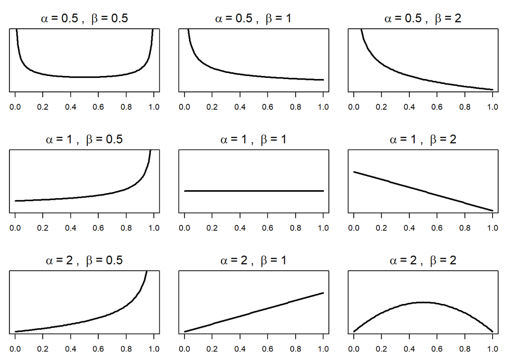

Figure 7.1: Density curves for the beta distribution of the prevalence parameter $\theta$, with various different values of $\alpha$ and $\beta$. Some are symmetrical about $0.5$, but others assign high probabilities to larger/smaller prevalences. Some are vague, with a large spread, but others are more concentrated and therefore suggest greater certainty.

Suppose that we observe $X = x$. How does this change our beliefs about $\theta$? The density of $\theta$ given $X = x$ is the **posterior distribution** of $\theta$, and is given by the relationship
$$\text{posterior} \propto \text{prior}\times \text{likelihood}$$
$$\Leftrightarrow \;\; f(\theta \mid x) \propto \theta^{\alpha-1}(1-\theta)^{\beta-1}\times \binom{n}{x}\theta^{x}(1-\theta)^{n-x}.$$
Since this is a proportionality relationship and we are thinking of this as a density for $\theta$, we can safely ignore any factors that do not depend on $\theta$. We get
$$\begin{eqnarray*}
f(\theta \mid x) & \propto & {\theta^{\alpha-1}(1-\theta)^{\beta-1}}\times \theta^{x}(1-\theta)^{n-x}\\
& = & {\theta^{(\alpha + x)-1}(1-\theta)^{(\beta + n-x)-1}}.
\end{eqnarray*}$$
We recognise that the right hand side is proportional to the density of a beta distribution. Therefore $f(\theta \mid x)$ must be the density of beta distribution with parameters $\alpha+x$ and $\beta + n - x$. Thus, the **posterior distribution** of $\theta$ given $X = x$ is
$$\theta \mid X=x \quad \sim \quad \text{Beta}(\alpha+x, \beta + n - x).$$
This is a general result: **if the likelihood of our data is binomial and the prior for its parameter is a beta distribution, the posterior will also be a beta distribution**. This is an example of a **conjugate prior** (where the posterior is the same kind of distribution as the prior).

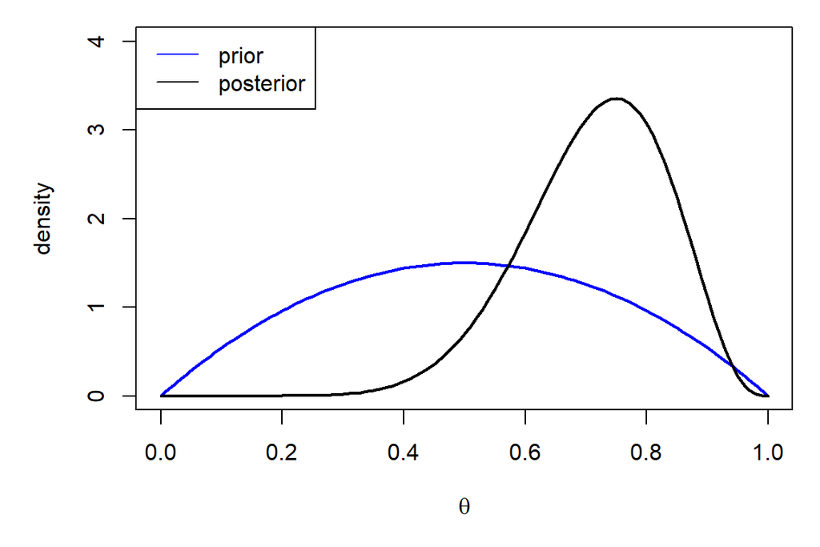

Figure 7.2: A comparison of the prior and posterior density functions. The prior is quite vague (had a large spread) and is symmetrical about $\theta = 0.5$. The posterior is more concentrated and, relative to the prior, assigns a much higher probabilities to values of $\theta$ close to the sample prevalence of $0.8$.

Suppose, for example, that our prior was $\text{Beta}(2,2)$, and that we took a sample of size $n = 10$, observing $x= 8$ diseased individuals. Then our posterior would be $\text{Beta}(10,4)$. In Figure 7.2, we see that this gives a sensible update of our beliefs. We initially believed that the prevalence of the disease was about $50\%$. But then we observed a sample where $80\%$ were diseased, which updated our beliefs in such a way that we are very confident that the prevalence is actually more than $50\%$.

Since we used a conjugate prior, this was a simple update of the parameters of the prior distribution. We observed $x$ diseased individuals and $n-x$ without the disease. Thus, the parameter $\alpha$ was updated to $\alpha + x$ and $\beta$ to $\beta + n - x$. If we observe another sample of $m$ drug users, and observe that $y$ are diseased and $m-y$ are healthy, then our posterior will become
$$\text{Beta}\left(\alpha + x + y, \beta + (n + m) -(x + y)\right).$$

## 7.3 Normal likelihood

**Example 7.3 (quality of life, continued)** Recall our example on the quality of life of patients suffering from COPD who are taking a new drug. We considered quality of life to be measured on a scale of $0$ (death) to $100$ (perfect health). Now define a new random variable $X$ that denotes a patient’s change in quality of life after taking the drug. Suppose that
$$X \sim N(\mu, \sigma^2)$$
with $\sigma^2$ **known** and $\mu$ **unknown**. The density of $X$ for any given $\mu$ is

$$\begin{eqnarray*}
f(x\mid \mu) & = & \underbrace{\frac{1}{\sigma\sqrt{2\pi}}}_{\text{does not depend on $\mu$}}
\exp\left\{-\frac{1}{2}\left(\frac{x-\mu}{\sigma}\right)^2\right\}\\
&\propto& \exp\left\{-\frac{1}{2}\left(\frac{x-\mu}{\sigma}\right)^2\right\}\\
& = & \exp\left\{-\frac{\mu^2-2\mu x + x^2}{2\sigma^2}\right\}\\
& = & \underbrace{\exp\left\{-\frac{x^2}{2\sigma^2}\right\}}_{\text{does not depend on $\mu$}}\exp\left\{-\frac{\mu^2-2\mu x}{2\sigma^2}\right\}\\\\
&\propto& \exp\left\{-\frac{\mu^2-2\mu x}{2\sigma^2}\right\}
\end{eqnarray*}$$

where proportionality here is **as a function of $\mu$**, since we want to think of this as a likelihood (i.e. as a function of the unknown parameter), which has allowed us to ignore any factors that do not depend on $\mu$. If we take a random sample of size $n$ from this distribution and observe realisations $x_1,\ldots,x_n$, the likelihood of these $n$ realisations is

$$\begin{eqnarray*}\prod_{i=1}^{n} f(x_{i} \mid \mu) & = & \prod_{i=1}^{n} \exp\left( -\frac{\mu^2-2\mu x_i}{2\sigma^2}\right).\end{eqnarray*}$$

Suppose that our uncertainty in $\mu$ is described by the prior distribution
$$\mu\sim N(\mu_1,\sigma_1^2)$$
for some parameters $\mu_1$ and $\sigma_1^2$ of our choice. Then the prior density for $\mu$ is

$$\begin{eqnarray*}
f(\mu) & = & \underbrace{\frac{1}{\sigma_1\sqrt{2\pi}}}_{\text{does not depend on $\mu$}}
\exp\left\{-\frac{1}{2}\left(\frac{\mu-\mu_1}{\sigma_1}\right)^2\right\}\\
& \propto & \exp\left\{-\frac{\mu^2 - 2\mu_1\mu + \mu_1^2}{2\sigma_1}\right\}\\
& = & \underbrace{\exp\left\{-\frac{\mu_1^2}{2\sigma_1}\right\}}_{\text{does not depend on $\mu$}}\exp\left\{-\frac{\mu^2 - 2\mu_1\mu}{2\sigma_1}\right\}\\
&\propto & \exp\left(-\frac{\mu^2-2\mu \mu_1}{2\sigma_1^2}\right)\\
& = & \exp\left(-\frac{\mu^2}{2}\sigma_1^{-2} + \mu (\mu_1 \sigma_1^{-2})\right)\\
& = & \exp\left(-\frac{\mu^2}{2}[\text{variance of prior}]^{-1} + \mu \times \text{mean of prior} \times[\text{variance of prior}]^{-1}\right).
\end{eqnarray*}$$

The posterior density of $\mu$ is proportional to the likelihood times the prior:

$$\begin{eqnarray*}
f(\mu\mid x_1,\ldots,x_n) & \propto &
\prod_{i=1}^n \exp\left\{-\frac{\mu^2-2\mu x_i}{2\sigma^2}\right\} \\
&& \times \exp\left(-\frac{\mu^2}{2}\sigma_1^{-2} + \mu (\mu_1 \sigma_1^{-2})\right).
\end{eqnarray*}$$

Combining the exponents,

$$\begin{eqnarray*}
f(\mu\mid x_1,\ldots,x_n) &\propto&
\prod_{i=1}^n \exp\left(-\frac{\mu^2-2\mu x_i}{2\sigma^2}\right)\\
&& \times \exp\left(-\frac{\mu^2}{2}\sigma_1^{-2} + \mu (\mu_1 \sigma_1^{-2})\right)\\
&=&
\exp\left(-\frac{1}{2\sigma^2}\sum_{i=1}^n (\mu^2-2\mu x_i)-\frac{1}{2\sigma_1^2}(\mu^2-2\mu \mu_1)\right) \\
& = & \exp\left\{-\frac{\mu^2}{2}\left(\frac{n}{\sigma^2}+\frac{1}{\sigma_1^2}\right) +\mu\left(\frac{1}{\sigma^2}\sum_{i=1}^n x_i+\frac{\mu_1}{\sigma_1^2}\right)\right\}\\
& = & \exp\left\{-\frac{\mu^2}{2}\left(\frac{n}{\sigma^2}+\frac{1}{\sigma_1^2}\right) +\mu\left(\frac{n\overline{x}}{\sigma^2}+\frac{\mu_1}{\sigma_1^2}\right)\right\}.
\end{eqnarray*}$$

But, as a function of $\mu$, this has the familiar form of the prior (which was normal):
$$\exp\left(-\frac{\mu^2}{2}(\text{variance})^{-1} + \mu (\text{mean}\times\text{variance}^{-1})\right),$$
and therefore our posterior density is proportional to the density of a normal distribution for $\mu$ with mean and variance (respectively)

$$\left(\frac{n\overline{x}}{\sigma^2}+\frac{\mu_1}{\sigma_1^2}\right) \times \frac{1}{\displaystyle \frac{n}{\sigma^2}+\frac{1}{\sigma_1^2}} \quad \text{and} \quad \frac{1}{\displaystyle \frac{n}{\sigma^2}+\frac{1}{\sigma_1^2}}.$$

Given that “proportionality implies equality” for density functions, this means that our posterior distribution for $\mu$ **must** be that normal distribution.

In summary, the posterior of $\mu$ is
$$\mu\mid x_1,\ldots,x_n \;\;\;\sim\;\;\; N\left(\displaystyle \frac{\displaystyle \frac{1}{\sigma^2}\sum_{i=1}^n x_i+\frac{\mu_1}{\sigma_1^2}}{\displaystyle \frac{n}{\sigma^2}+\frac{1}{\sigma_1^2}}, \left(\frac{n}{\sigma^2}+\frac{1}{\sigma_1^2}\right)^{-1}\right)$$
and the normal distribution is a **conjugate prior** for the mean of a normal distribution.

For example, suppose that $\sigma^2 = 4$ and we take a random sample $X_i \sim N(\mu,4)$. If we assume a prior $\mu\sim N(8,9)$, we can find the posterior of $\mu$ given the observations

$$18.36,~~16.17,~~10.21,~~11.07,~~18.32,~~6.03,~18.42,~~8.04,~~13.53$$

We have $n = 9$, $\sigma_0^2=4, \sigma_1^2=9$ and $\mu_1=8$. We compute $\sum x_i =120.15$. Then the posterior for $\mu$ is normal with mean
$$\frac{\displaystyle \frac{1}{\sigma^2}\sum_{i=1}^n x_i+\frac{\mu_1}{\sigma_1^2}}{\displaystyle \frac{n}{\sigma^2}+\frac{1}{\sigma_1^2}}=
\frac{\displaystyle \frac{1}{4} 120.15+\frac{8}{9}}{\displaystyle \frac{9}{4}+\frac{1}{9}}=13.098$$
and variance
$$\left(\frac{n}{\sigma^2}+\frac{1}{\sigma_1^2}\right)^{-1}=
\left(\frac{9}{4}+\frac{1}{9}\right)^{-1}=\frac{1}{2.361111}=0.4235.$$